# TASK 2 CODSOFT

## TASK - 2

## IRIS FLOWER CLASSIFICATION

## JAN BATCH A30

The Iris dataset is a widely used dataset in the field of machine learning and statistics. It was introduced by the British biologist and statistician Ronald A. Fisher in his 1936 paper "The Use of Multiple Measurements in Taxonomic Problems."

The dataset consists of 150 samples from three different species of Iris flowers: setosa, versicolor, and virginica. For each species, there are four features measured:

Sepal Length (in cm)

Sepal Width (in cm)

Petal Length (in cm)

Petal Width (in cm)

In summary, the Iris dataset is a simple yet powerful dataset that is often used for introductory machine learning tasks, particularly for classification. The compact nature of the dataset makes it easy to work with, and its features are numerical, making it suitable for various machine learning algorithms.

```python
# Import necessary libraries
import numpy as np
import pandas as pd
import matplotlib.pyplot as plt
import seaborn as sns
from sklearn.model_selection import train_test_split
from sklearn.preprocessing import StandardScaler
from sklearn.neighbors import KNeighborsClassifier
from sklearn.metrics import classification_report, confusion_matrix
from sklearn.metrics import accuracy_score
```

```python
# Load the dataset
iris_data = pd.read_csv('C:/Users/MANOJ S/Downloads/archive (15)/IRIS.csv')
iris_data
```

|  | sepal_length | sepal_width | petal_length | petal_width | species |
| --- | --- | --- | --- | --- | --- |
| 0 | 5.1 | 3.5 | 1.4 | 0.2 | Iris-setosa |
| 1 | 4.9 | 3.0 | 1.4 | 0.2 | Iris-setosa |
| 2 | 4.7 | 3.2 | 1.3 | 0.2 | Iris-setosa |
| 3 | 4.6 | 3.1 | 1.5 | 0.2 | Iris-setosa |
| 4 | 5.0 | 3.6 | 1.4 | 0.2 | Iris-setosa |
| ... | ... | ... | ... | ... | ... |
| 145 | 6.7 | 3.0 | 5.2 | 2.3 | Iris-virginica |
| 146 | 6.3 | 2.5 | 5.0 | 1.9 | Iris-virginica |
| 147 | 6.5 | 3.0 | 5.2 | 2.0 | Iris-virginica |
| 148 | 6.2 | 3.4 | 5.4 | 2.3 | Iris-virginica |
| 149 | 5.9 | 3.0 | 5.1 | 1.8 | Iris-virginica |

150 rows × 5 columns

```python
# Display the first few rows of the dataset
print(iris_data.head())
```

```
   sepal_length  sepal_width  petal_length  petal_width      species
0           5.1          3.5           1.4          0.2  Iris-setosa
1           4.9          3.0           1.4          0.2  Iris-setosa
2           4.7          3.2           1.3          0.2  Iris-setosa
3           4.6          3.1           1.5          0.2  Iris-setosa
4           5.0          3.6           1.4          0.2  Iris-setosa
```

```python
# Data preprocessing
X = iris_data.iloc[:, :-1]  # Features (sepal and petal measurements)
y = iris_data.iloc[:, -1]   # Target variable (species)
```

```python
X
```

|  | sepal_length | sepal_width | petal_length | petal_width |
| --- | --- | --- | --- | --- |
| 0 | 5.1 | 3.5 | 1.4 | 0.2 |
| 1 | 4.9 | 3.0 | 1.4 | 0.2 |
| 2 | 4.7 | 3.2 | 1.3 | 0.2 |
| 3 | 4.6 | 3.1 | 1.5 | 0.2 |
| 4 | 5.0 | 3.6 | 1.4 | 0.2 |
| ... | ... | ... | ... | ... |
| 145 | 6.7 | 3.0 | 5.2 | 2.3 |
| 146 | 6.3 | 2.5 | 5.0 | 1.9 |
| 147 | 6.5 | 3.0 | 5.2 | 2.0 |
| 148 | 6.2 | 3.4 | 5.4 | 2.3 |
| 149 | 5.9 | 3.0 | 5.1 | 1.8 |

150 rows × 4 columns

```python
y
```

```
0         Iris-setosa
1         Iris-setosa
2         Iris-setosa
3         Iris-setosa
4         Iris-setosa
            ...
145    Iris-virginica
146    Iris-virginica
147    Iris-virginica
148    Iris-virginica
149    Iris-virginica
Name: species, Length: 150, dtype: object
```

```python
# Split the dataset into training and testing sets
X_train, X_test, y_train, y_test = train_test_split(X, y, test_size=0.2, random_state=42)
```

```python
# Standardize the feature values
scaler = StandardScaler()
X_train = scaler.fit_transform(X_train)
X_test = scaler.transform(X_test)
```

```python
X_train
```

[output not shown]

[output cut: 65 more lines]

[output not shown]

```python
X_test
```

```
array([[ 0.35451684, -0.57925837,  0.5576453 ,  0.02332414],
       [-0.13307079,  1.67028869, -1.16259727, -1.17620281],
       [ 2.30486738, -1.02916778,  1.81915651,  1.48941263],
       [ 0.23261993, -0.35430366,  0.44296246,  0.42316645],
       [ 1.2077952 , -0.57925837,  0.61498672,  0.28988568],
       [-0.49876152,  0.77046987, -1.27728011, -1.04292204],
       [-0.2549677 , -0.35430366, -0.07311031,  0.15660491],
       [ 1.32969211,  0.09560575,  0.78701097,  1.48941263],
       [ 0.47641375, -1.9289866 ,  0.44296246,  0.42316645],
       [-0.01117388, -0.80421307,  0.09891395,  0.02332414],
       [ 0.84210448,  0.32056046,  0.78701097,  1.08957031],
       [-1.23014297, -0.12934896, -1.33462153, -1.44276436],
       [-0.37686461,  0.99542457, -1.39196294, -1.30948358],
       [-1.10824606,  0.09560575, -1.27728011, -1.44276436],
       [-0.86445224,  1.67028869, -1.27728011, -1.17620281],
       [ 0.59831066,  0.54551516,  0.5576453 ,  0.55644722],
       [ 0.84210448, -0.12934896,  1.18840091,  1.35613185],
       [-0.2549677 , -1.25412249,  0.09891395, -0.10995664],
       [-0.13307079, -0.57925837,  0.44296246,  0.15660491],
       [ 0.72020757, -0.57925837,  1.07371807,  1.35613185],
       [-1.35203988,  0.32056046, -1.21993869, -1.30948358],
       [ 0.35451684, -0.12934896,  0.67232814,  0.82300877],
       [-0.98634915,  0.77046987, -1.21993869, -1.04292204],
       [ 0.72020757, -0.57925837,  1.07371807,  1.22285108],
       [ 2.5486612 ,  1.67028869,  1.53244942,  1.08957031],
       [ 1.08589829, -0.12934896,  0.84435239,  1.48941263],
       [ 1.08589829, -1.25412249,  1.18840091,  0.82300877],
       [ 1.2077952 ,  0.32056046,  1.24574233,  1.48941263],
       [-1.23014297, -0.12934896, -1.33462153, -1.17620281],
       [-1.23014297,  0.09560575, -1.21993869, -1.30948358]])
```

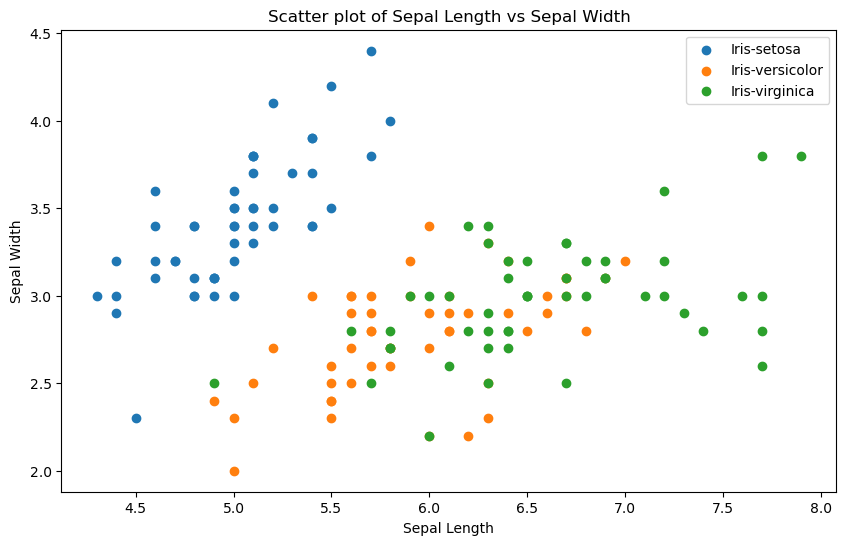

```python
# Scatter plot of sepal length vs. sepal width
plt.figure(figsize=(10, 6))
for species in iris_data['species'].unique():
    plt.scatter(iris_data[iris_data['species'] == species]['sepal_length'],
                iris_data[iris_data['species'] == species]['sepal_width'],
                label=species)
plt.title('Scatter plot of Sepal Length vs Sepal Width')
plt.xlabel('Sepal Length')
plt.ylabel('Sepal Width')
plt.legend()
plt.show()
```

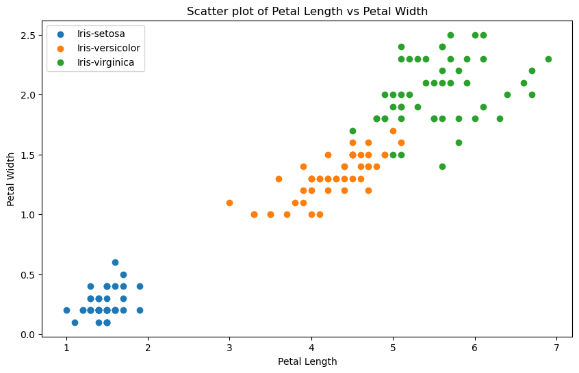

```python
# Scatter plot of petal length vs. petal width
plt.figure(figsize=(10, 6))
for species in iris_data['species'].unique():
    plt.scatter(iris_data[iris_data['species'] == species]['petal_length'],
                iris_data[iris_data['species'] == species]['petal_width'],
                label=species)

plt.title('Scatter plot of Petal Length vs Petal Width')
plt.xlabel('Petal Length')
plt.ylabel('Petal Width')
plt.legend()
plt.show()
```

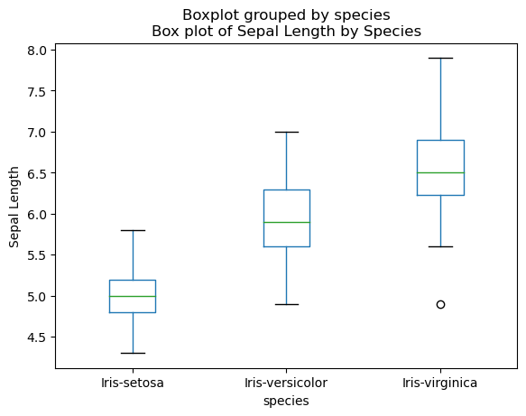

```python
# Box plot for sepal length
plt.figure(figsize=(10, 6))
iris_data.boxplot(column='sepal_length', by='species', grid=False)
plt.title('Box plot of Sepal Length by Species')
plt.ylabel('Sepal Length')
plt.show()
```

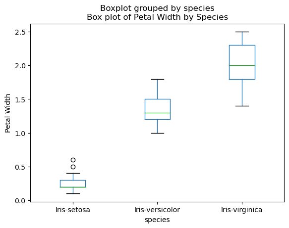

```python
# Box plot for petal width
plt.figure(figsize=(10, 6))
iris_data.boxplot(column='petal_width', by='species', grid=False)
plt.title('Box plot of Petal Width by Species')
plt.ylabel('Petal Width')
plt.show()
```

```python
# Build the K-nearest neighbors (KNN) classifier
k = 3  # You can adjust the value of k based on your preference
knn_model = KNeighborsClassifier(n_neighbors=k)
knn_model.fit(X_train, y_train)
```

```
KNeighborsClassifier(n_neighbors=3)
```

```python
# Make predictions on the test set
y_pred = knn_model.predict(X_test)
```

```
C:\Users\MANOJ S\anaconda3\lib\site-packages\sklearn\neighbors\_classification.py:228: FutureWarning: Unlike other reduction functions (e.g. `skew`, `kurtosis`), the default behavior of `mode` typically preserves the axis it acts along. In SciPy 1.11.0, this behavior will change: the default value o…
  mode, _ = stats.mode(_y[neigh_ind, k], axis=1)
```

```python
# Evaluate the performance of the model
print("Confusion Matrix:\n", confusion_matrix(y_test, y_pred))
print("\nClassification Report:\n", classification_report(y_test, y_pred))
print("\nAccuracy:", accuracy_score(y_test, y_pred))
```

```
Confusion Matrix:
 [[10  0  0]
 [ 0  9  0]
 [ 0  0 11]]

Classification Report:
                  precision    recall  f1-score   support

    Iris-setosa       1.00      1.00      1.00        10
Iris-versicolor       1.00      1.00      1.00         9
 Iris-virginica       1.00      1.00      1.00        11

       accuracy                           1.00        30
      macro avg       1.00      1.00      1.00        30
   weighted avg       1.00      1.00      1.00        30


Accuracy: 1.0
```

High Accuracy:

The model achieved an accuracy of 100%, indicating that it correctly classified all instances in the test set. Perfect Precision, Recall, and F1-Score:

Precision, recall, and f1-score are all 1.0 for each class, demonstrating the model's ability to make accurate predictions across all species (setosa, versicolor, virginica). Confusion Matrix:

The confusion matrix shows zeros outside the diagonal, indicating no misclassifications. Each class is correctly identified. Robust Generalization:

The model appears to generalize well to new, unseen data, as evidenced by the high scores across all evaluation metrics. Visualizations:

The scatter plots and box plots provide insights into the distribution of sepal and petal measurements for each species, supporting the model's ability to distinguish between classes. Caution on Overfitting:

Given the small size of the dataset, it's important to be cautious about overfitting. If the dataset is limited, consider exploring cross-validation techniques to ensure the model's robustness. Model Reliability:

The consistently high scores across various metrics indicate that the model is reliable and performs well on the Iris flower classification task.